Iº Fórum da RENAVEH · 2026

# Detecta Síndromes

O sinal que aparece antes do diagnóstico chegar

Marcelo Bragatte · Instituto Todos pela Saúde (ITpS)

## Sobre o ITpS

- **Instituto Todos pela Saúde (ITpS):** fortalece a vigilância e a resposta em saúde pública.
- **Programa de Epidemiologia Digital:** transforma dados que já existem em inteligência acionável.
- Equipe compacta, foco em provas de conceito (POC) e transferência tecnológica.
- Abordagem aberta e FAIR, baixo custo e foco no município.

## Motivação

**Quando o boletim chega, o sinal já passou** — a vigilância tradicional espera a confirmação laboratorial.

Hospitais e UPAs são **sensores sensíveis** do SUS: casos graves incomuns, mudanças de perfil, aumentos inesperados — em **texto não estruturado**.

Cada semana de atraso é uma semana de intervenção que não acontece. O Detecta lê a triagem e age de forma **oportuna**.

## O motor do Detecta

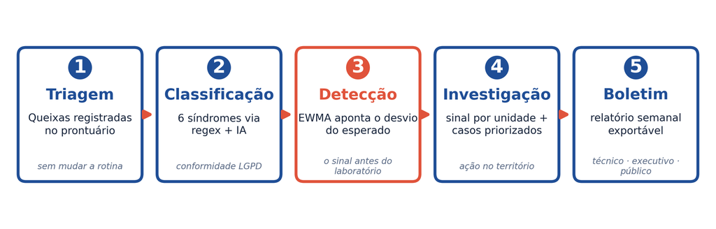

Pipeline automatizado: dados → síndromes → dashboard → alertas · **+5 milhões de anamneses**

## Onde já estamos

- 80 municípios — todas as capitais e as 5 regiões do país.
- **Foco no município:** implantação local e autonomia da vigilância.
- **3 fontes:** SIVEP-Gripe (dados públicos), envio municipal direto e articulação.
- Baixo custo de entrada (SaaS), com dados públicos de SRAG sem exigir integração.

## 6 síndromes, atualizadas em 48h

- +5 milhões de anamneses captadas e agrupadas em síndromes.
- Respiratória · Diarreica · Exantemática · Ictérica · Neurológica · Outras febris.
- Classificação no padrão SINAN a partir do texto clínico (regex + IA).
- **EWMA sinaliza cenários:** Normal · Moderado · Elevado.

## Tempo — detecção de anomalias (EWMA)

[figure not shown]

## Pessoa — quem e quais sintomas

[figure not shown]

[figure not shown]

## Lugar — mapa por unidade de saúde

[figure not shown]

## Relatórios automatizados

[figure not shown]

[figure not shown]

## Qualidade do dado — INV e DQI

[figure not shown]

## Parcerias, reconhecimento e validação

- **Parcerias:** OPAS, MS/SVSA, MS/SAPS, UKHSA, INOVA-HC, SMS de +10 cidades.
- **AESOP (Fiocruz):** referência nacional e inspiração — codificação (CID/CIAP) e indicadores de qualidade do dado.
- Homologado pelo LabInovaSUS (proposta de matchfunding SEIDIGI).
- Validação contra síndromes respiratórias, Infodengue e DDA — em fase final.
- **Foco no município:** detecção oportuna e autonomia da vigilância local.

## Gatilho para verificação e investigação

[figure not shown]

## Detecta Docs — integrar e ser parceiro

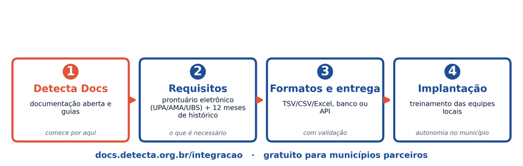

**docs.detecta.org.br/integracao** · gratuito para municípios parceiros

# Obrigado!

Como o Detecta pode reforçar os “sensores sensíveis” e a RENAVEH?

Marcelo Bragatte · ITpS · marcelo.bragatte@itps.org.br · itps.org.br